# R exercises

Preprocessing and EDA

This notebook takes you through working with expenses data. First, [download the latest MPs’ expenses from IPSA](http://www.theipsa.org.uk/mp-costs/other-published-data/) - *make sure you select Individual Claims* to get the granular data.

## Import data

Now to read that CSV file into an object we can work with in R. Note: the CSV must be in the same folder as your R project.

```r
expenses1718 <- read.csv("Individual_claims_for_17_18.csv")
```

## Generate a summary

We can summarise the whole dataset like this:

```r
summary(expenses1718)
```

```
##     Year               Date                    Claim.No.
##  17_18:11747   01/04/2017:1943   Payment To Supplier:2578
##                19/04/2017: 614   579422             :  40
##                20/04/2017: 544   581012             :  33
##                24/04/2017: 489   579136             :  31
##                03/04/2017: 482   579134             :  28
##                21/04/2017: 466   581081             :  28
##                (Other)   :7209   (Other)            :9009
##            MP.s.Name                 MP.s.Constituency
##  Owen Paterson  :   95   North Shropshire CC  :   95
##  Glyn Davies    :   89   Montgomeryshire CC   :   89
##  Brendan O'Hara :   78   Argyll and Bute CC   :   78
##  Ben Gummer     :   74   Ipswich BC           :   74
##  Chris Stephens :   67   Glasgow South West BC:   67
##  David Warburton:   66   Somerton and Frome CC:   66
##  (Other)        :11278   (Other)              :11278
##              Category                            Expense.Type
##  Office Costs    :4612   Own Vehicle Car               :2034
##  MP Travel       :3277   Accommodation Rent            :1074
##  Accommodation   :1629   Const Office Tel. Usage/Rental: 797
##  Staff Travel    :1482   Stationery Purchase           : 795
##  Staffing        : 672   Own Vehicle Car MP Staff      : 775
##  Dependant Travel:  54   Const Office Rent             : 556
##  (Other)         :  21   (Other)                       :5716
##                       Short.Description
##                                :4329
##  Banner                        : 574
##  PRU                           : 293
##  Office Costs                  : 269
##  Direct Travel Import 18/04/201: 186
##  XMA Ltd                       : 153
##  (Other)                       :5943
##                                 Details
##                                     :4360
##  April Banner invoice for stationery: 368
##  PRU Subscription                   : 175
##  XMA April invoice for stationery   : 153
##  Cross reference software           : 118
##  BT BILL PAYMENT 2                  :  97
##  (Other)                            :6476
```

[output cut: 17 more lines]

```
##  Min.   :-1000.00   Min.   :-1000.0   Min.   : 0.00000
##  1st Qu.:   13.26   1st Qu.:   13.2   1st Qu.: 0.00000
##  Median :   48.90   Median :   48.9   Median : 0.00000
##  Mean   :  322.30   Mean   :  322.3   Mean   : 0.00485
##  3rd Qu.:  205.48   3rd Qu.:  205.5   3rd Qu.: 0.00000
##  Max.   :16170.00   Max.   :16170.0   Max.   :40.00000
##
##  Amount.Repaid            Status                  Reason.If.Not.Paid
##  Min.   :   0.0000   Not Paid:    3                        :11744
##  1st Qu.:   0.0000   Paid    :11724   Insufficient Evidence:    1
##  Median :   0.0000   Repaid  :   20   Not Under Scheme     :    2
##  Mean   :   0.2442
##  3rd Qu.:   0.0000
##  Max.   :1091.8200
##
```

Note how numerical columns are summarised differently to text columns. We can get a summary of just one column like this:

```r
summary(expenses1718$Category)
```

```
##          Accommodation       Dependant Travel Miscellaneous Expenses
##                   1629                     54                     12
##              MP Travel           Office Costs           Staff Travel
##                   3277                   4612                   1482
##               Staffing             Winding Up
##                    672                      9
```

Or a numerical one:

```r
summary(expenses1718$Amount.Claimed)
```

```
##     Min.  1st Qu.   Median     Mean  3rd Qu.     Max.
## -1000.00    13.26    48.90   322.30   205.48 16170.00
```

## Join data

[Download another year’s data from IPSA](http://www.theipsa.org.uk/mp-costs/other-published-data/) - remember again to select *Individual Claims*.

Bring it into R in the same way:

```r
expenses1617 <- read.csv("Individual_claims_for_16_17.csv")
```

Because we want to add new *rows* with this join, we use `rbind` like so:

```r
expenses16to18 <- rbind(expenses1617,expenses1718)
```

## Export the results

That might be all we want to do, then export so we can work with it in Excel.

```r
write.csv(expenses16to18, "expenses2016to2017.csv")
```

## Create a subset

Now let’s filter this to an MP from one constituency:

```r
expensesedgbaston <- subset(expenses16to18, expenses16to18$MP.s.Name == "Stephen Kinnock")
```

## Ask a question

You can ask all sorts of questions…

```r
totalexpensesclaimed <- sum(expenses16to18$Amount.Claimed)
totalexpensesclaimed
```

```
## [1] 30427475
```

```r
biggestexpenseclaimed <- max(expenses16to18$Amount.Claimed)
biggestexpenseclaimed
```

```
## [1] 19200
```

## Generate new data

We can also create a new column based on other columns. For example we could calculate a difference:

```r
expenses16to18$claimdifference <- expenses16to18$Amount.Claimed - expenses16to18$Amount.Paid
#Let's see what the biggest difference was
max(expenses16to18$claimdifference)
```

```
## [1] 596.65
```

Likewise we could extract parts of data by using a text function like `substring`:

```r
#substring needs 3 ingredients:
#a text object, a starting position to start grabbing characters from, and an end position
#The first two characters of each date is the day; the third character is a slash, and the 4th and 5th characters are used to indicate the month, so that's what we want
expenses16to18$month <- substring(expenses16to18$Date,4,5)
#Show the different entries in that new field
table(expenses16to18$month)
```

```
##
##    01    02    03    04    05    06    07    08    09    10    11    12
## 14395 13115 14971 28933 17569 15801 15153 10071 14409 15032 16171 13184
```

Another type of new data might be *categorisation*. For example performing a test will generate a series of TRUE/FALSE values:

```r
expenses16to18$above10k <- expenses16to18$Amount.Claimed > 10000
#See a table counting occurrences of each value in the field
table(expenses16to18$above10k)
```

```
##
##  FALSE   TRUE
## 188743     61
```

Calculations can be used instead of raw numbers, for example:

```r
expenses16to18$aboveaverage <- expenses16to18$Amount.Claimed > mean(expenses16to18$Amount.Claimed)
#Note that 'average' doesn't mean halfway
table(expenses16to18$aboveaverage)
```

```
##
##  FALSE   TRUE
## 156703  32101
```

```r
#Only 17% of claims are 'above average'
32101/(156703+32101)
```

```
## [1] 0.1700229
```

## Visualising

We can use the `ggplot2` library to visualise data in different ways. First we need to initialise it:

```r
#ggplot2 should already be installed, but if you get a message that it isn't, uncomment this next line and run that first
#install.packages("ggplot2")
#Initialise the library
library(ggplot2)
```

Then this code generates a histogram:

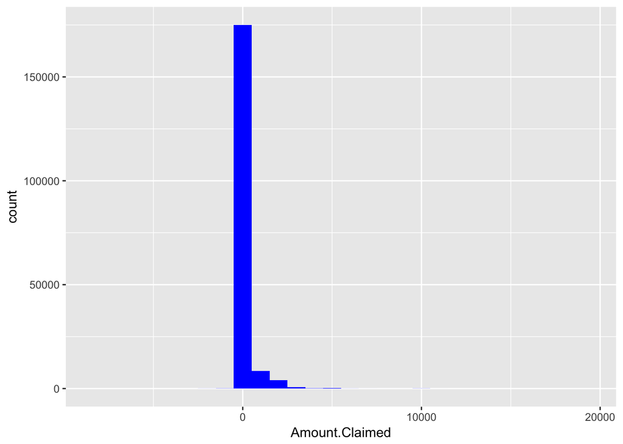

```r
#use the ggplot function with our dataset
ggplot(expenses16to18) +
  geom_histogram(aes(x=Amount.Claimed), #specify a histogram, and the column Amount.Claimed
                 binwidth=1000, #specify how wide each 'bin' (column) is
                 fill="blue") #specify a fill colour
```

The code to generate a density plot is similar:

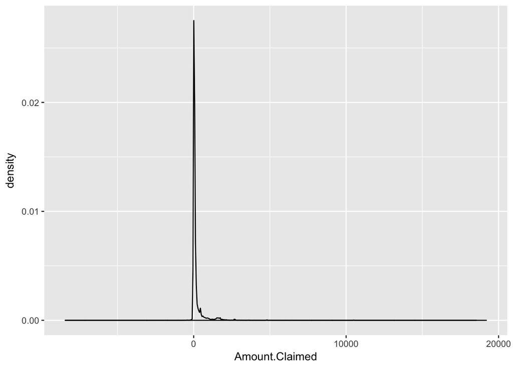

```r
#library(scales) #this allows us to add dollars to the numbers
#use the ggplot function with our dataset
ggplot(expenses16to18) +
  geom_density(aes(x=Amount.Claimed)) #specify a histogram, and the column Amount.Claimed
```

```r
                 #+ scale_x_continuous(labels=dollar) #specify the x axis labels as dollar amounts if needed
```

And for a column chart:

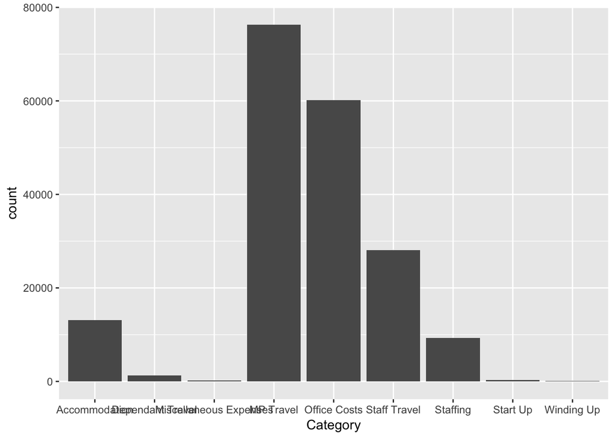

```r
#use the ggplot function with our dataset
ggplot(expenses16to18) +
  geom_bar(aes(x=Category)) #this needs to be a category, and entries will be counted
```

We can flip the axes by adding `+ coord_flip()` if we have a lot of categories and want a bar chart from the side - although with 650 categories it will still be difficult to read:

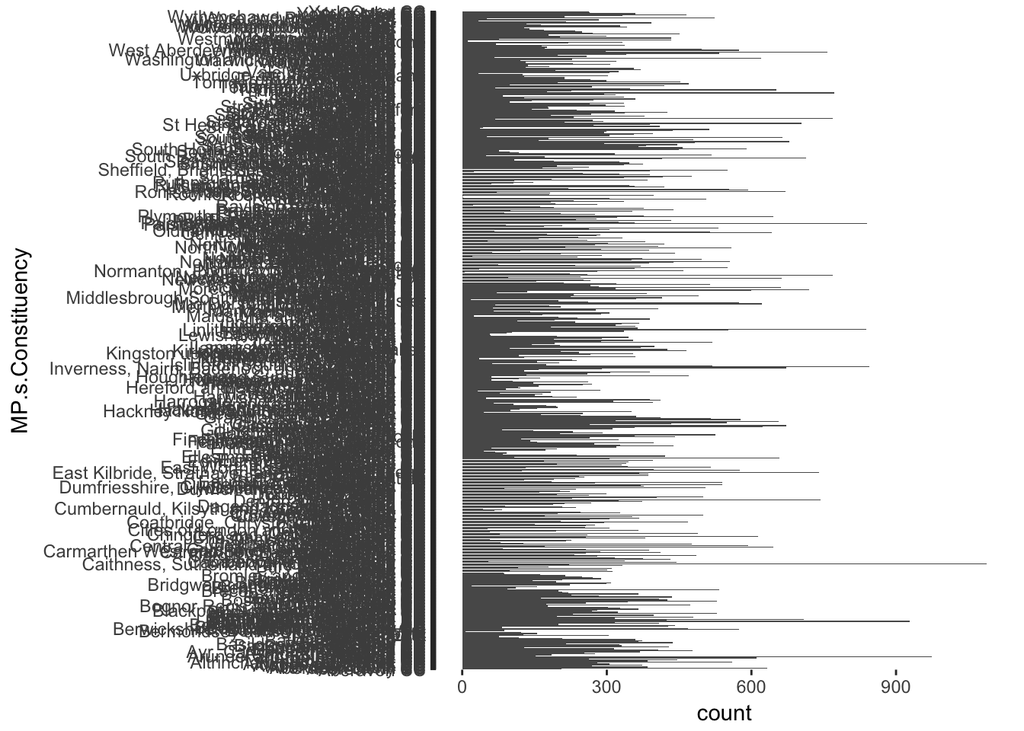

```r
#use the ggplot function with our dataset
ggplot(expenses16to18) +
  geom_bar(aes(x=MP.s.Constituency)) + coord_flip()
```

So we can add `theme` with arguments to specify the style:

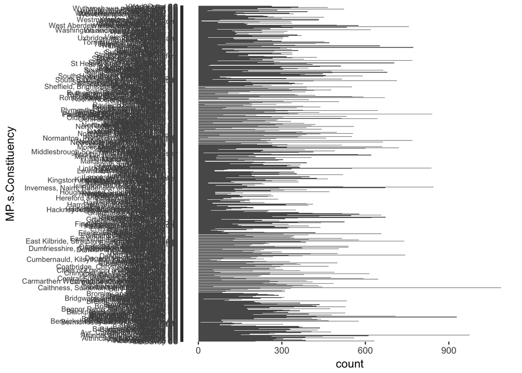

```r
#use the ggplot function with our dataset
ggplot(expenses16to18) +
  geom_bar(aes(x=MP.s.Constituency)) + coord_flip() + theme(axis.text.y = element_text(size=rel(0.8)))
```